# R Notebook

# Libraries

```r
if(!require('downloader')) {
  install.packages('downloader')
  library('downloader')
}

if(!require('networkD3')) {
  install.packages('networkD3')
  library('networkD3')
}

if(!require('igraph')) {
  install.packages('igraph')
  library('igraph')
}

if(!require('htmlwidgets')) {
  install.packages('htmlwidgets')
  library('htmlwidgets')
}


if(!require('plotly')) {
  install.packages('plotly')
  library('plotly')
}
```

# Load the data

```r
url <- "https://www.stats.ox.ac.uk/~snijders/siena/Glasgow_data.zip"
download(url, dest="dataset.zip", mode="wb")
unzip ("dataset.zip", exdir = "./")
```

```r
load("Glasgow-demographic.RData")
load("Glasgow-friendship.RData")
load("Glasgow-substances.RData")
load("Glasgow-various.RData")

remove(money)
remove(romantic)
remove(alcohol)
remove(cannabis)
remove(friendship.2)
```

```r
age <- t(data.frame(as.list(age)))
sex.F <- t(data.frame(as.list(sex.F)))
```

```r
tobacco <- tobacco[, -2]  #we need only time 1 and time 3
tobacco <- as.data.frame(tobacco)
tb1_na <- which(is.na(tobacco$t1))
tb3_na <- which(is.na(tobacco$t3))
tb_na <- sort(unique(c(tb1_na, tb3_na)))

rn_na <- rownames(tobacco)[tb_na]
print(rn_na)
```

```
##  [1] "s009" "s017" "s024" "s025" "s031" "s040" "s048" "s063" "s067" "s094"
## [11] "s096" "s102" "s103" "s104" "s119" "s124" "s128" "s129" "s133" "s136"
## [21] "s145" "s153" "s154" "s155" "s156" "s157" "s158" "s159" "s160"
```

# Time 1

## First matrix: number of close friends at time 1.

1. Remove row and columns based on rn_na vector.

```r
f1 <- friendship.1[ !rownames(friendship.1) %in% rn_na,
                    !colnames(friendship.1) %in% rn_na]
```

2. Check if there are other NAs.

```r
any(is.na(f1))
```

```
## [1] FALSE
```

3. We want to focus only on strong relationship:
   - code 1 stands for “best friend”.
   - code 2 for “just friends”. Replace it with value 0.
   - code 0 stands for “no friends”.
   - code 10 indicates structural absence of the tie. Replace it with value 0.

```r
unique(as.vector(f1))
```

```
## [1] 0 1 2
```

```r
f1[f1 == 2] <- 0
unique(as.vector(f1))
```

```
## [1] 0 1
```

```r
# friendship matrix at time 1
#head(f1)
```

### Visualize network of friends at time 1

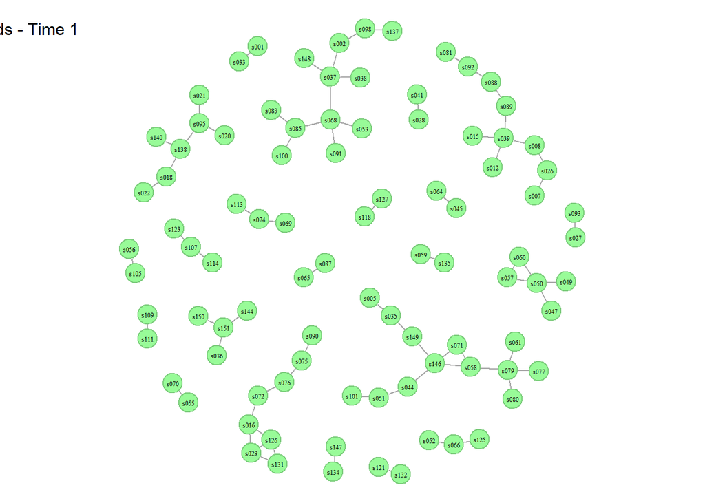

```r
# Make an Igraph object
g1 <- graph_from_adjacency_matrix(f1,
                                  mode="max",
                                  #weighted = NULL,
                                  diag = F)

isolated <- which(degree(g1)==0)
g1 <- delete.vertices(g1, isolated)

# Plot
par(mar=c(0,0,0,0))
#plot(g1, layout = layout_nicely(g1))
plot(g1, layout=layout_nicely(g1),
     vertex.size=9,
     vertex.color = "palegreen",
     vertex.label.cex=0.4,
     vertex.frame.color="palegreen3",
     vertex.label.color= "black")
text(-1.5,1,"Friends - Time 1", cex=1)
```

```r
# Since for the interactive network we need a dataframe, we will
# create a dataframe to store the indices of the 1 values ("best friends")
df1 = data.frame(row=character(), column=character())

# loop through the matrix and get the indices of the 1 values
for (i in 1:nrow(f1)) {
  for (j in 1:ncol(f1)) {
    if (f1[i, j] == 1) {
      df1 = rbind(df1, data.frame(row= rownames(f1)[i], column=colnames(f1)[j]))
    }
  }
}

# remove the first row which is empty
df1 = df1[-1,]

# print the dataframe
print(df1)
```

```
##     row column
## 2  s005   s035
## 3  s007   s026
## 4  s008   s026
## 5  s018   s022
## 6  s018   s138
## 7  s022   s018
## 8  s026   s007
## 9  s026   s008
## 10 s029   s016
## 11 s029   s126
## 12 s029   s131
## 13 s033   s001
## 14 s035   s149
## 15 s037   s002
```

[output cut: 75 more lines]

```r
# Interactive network
# Plot
p <- simpleNetwork(df1, height="100px", width="100px",
                  nodeColour = "palegreen",
                  linkColour = "#666",
                  fontFamily = "serif",
                  opacity = 0.9,
                  zoom = T)

p
```

[interactive chart not shown]

```r
#code to  save the widget

saveWidget(p, file=paste0( getwd(), "/networkInteractive.html"))
```

## Second matrix: close friends weighted by smoking behaviour.

Let’s take the first matrix *f1* (the friendship at time one) and multiply it by the row vector of the smoking behaviour at time 1.

1. As done before, let’s remove rows containing or referring to subjects with not available data.

```r
tobacco <- tobacco[!rownames(tobacco) %in% rn_na, ]

head(tobacco)
```

|  | t1 | t3 |
| --- | --- | --- |
| s001 | 2 | 1 |
| s002 | 1 | 1 |
| s003 | 3 | 3 |
| s004 | 1 | 1 |
| s005 | 1 | 1 |
| s006 | 3 | 3 |

2. Take the first column (smoking behavior at time 1) as a row vector.

```r
tb1 <- as.vector(tobacco$t1)
```

3. Tobacco use has the scores 1 (non), 2 (occasional) and 3 (regular, i.e. more than once per week). Replace 1 with 0, while 2 (occasional) and 3 (regular) with 1.

```r
tb1[tb1 == 1] <- 0
tb1[tb1 == 3| tb1 == 2] <- 1
```

4. Multiply *f1* matrix by *tb1* vector.

```r
f_tb1 = t(t(f1) * tb1)
unique(as.vector(f_tb1))
```

```
## [1] 0 1
```

### Visualize network of friends weighted by smoking behaviour at time 1

```r
#Create a dataframe with smoking behaviour for each subject
df_smoking <- data.frame(smoke = tobacco$t1, name = rownames(tobacco) )
df_smoking <- df_smoking[!rownames(df_smoking) %in% rn_na,]
df_smoking$smoke <- ifelse(df_smoking$smoke == 1, "No","Yes" )
```

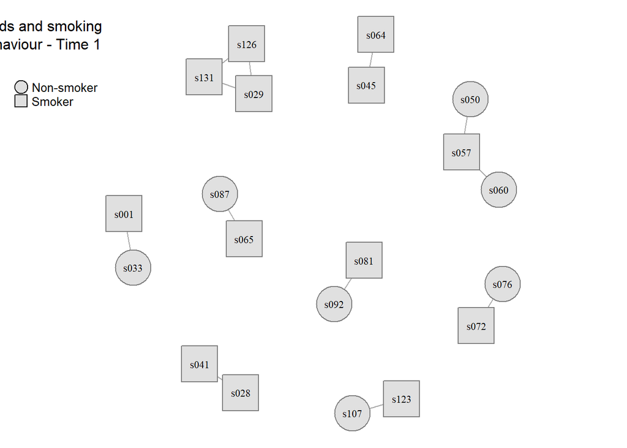

```r
# Make an Igraph object
g_tb1 <- graph_from_adjacency_matrix(f_tb1,
                                  mode="undirected",
                                  #weighted = NULL,
                                  diag = F)

# Color the nodes by smoking behavior
V(g_tb1)$shape <- ifelse(df_smoking$smoke== "No", "circle", "square")

isolated <- which(degree(g_tb1)==0)
g_tb1 <- delete.vertices(g_tb1, isolated)

# Plot
par(mar=c(0,0,0,0))
#plot(g1, layout = layout_nicely(g1))
plot(g_tb1, layout=layout_nicely(g_tb1),
     vertex.size=19,
     vertex.label.cex=0.7,
     vertex.color = "grey88",
     vertex.frame.color="gray48",
     vertex.label.color= "black")
text(-1.5,1,"   Friends and smoking
     behaviour - Time 1", cex=1)
legend(x=-1.6, y=0.8,
       legend= c("Non-smoker", "Smoker"),
       pch = c(21,22),  pt.bg= c('gray88', "gray88"),
       bty = "n" , pt.cex = 2, cex = 0.8,
       text.col="black" , horiz = F)
```

## Third matrix: gender (1 = same, 0 = different)

The gender information is coded 1 for boys and 2 for girls.

1. Remove rows referring to subjects with missing information.

```r
gender <- sex.F[!rownames(sex.F) %in% rn_na]
```

2. Create a matrix where 1 stands for same gender, 0 different.

```r
same_gender <- outer(gender, gender, function(a, b) as.integer(a == b))
dimnames(same_gender) <- list(rownames(f1), rownames(f1))
#head(same_gender)
```

3. Now, let’s perform an elementwise multiplication between the second matrix (friends and regular smoking behavior at time 1), with the gender matrix.

```r
f_tb1_gdr = f_tb1 * same_gender
```

### Visualize network of friends weighted by smoking behaviour and according to their gender at time 1

```r
#Create a dataframe with gender for each subject
df_gender <- data.frame(sex = sex.F, name = rownames(sex.F) )
df_gender <- df_gender[!rownames(df_gender) %in% rn_na,]
df_gender_smoking <- merge(df_gender, df_smoking)
```

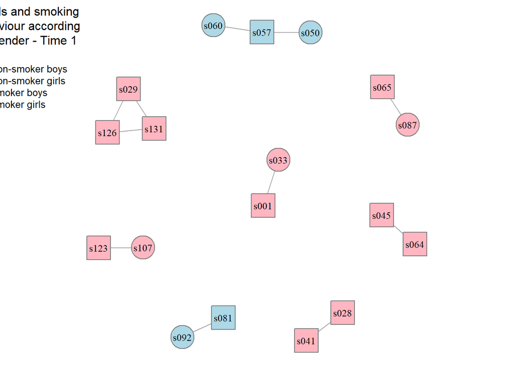

```r
# Make an Igraph object
g_tb1_gdr <- graph_from_adjacency_matrix(f_tb1_gdr,
                                  mode="undirected",
                                  #weighted = NULL,
                                  diag = F)

# Color the nodes by gender
V(g_tb1_gdr)$color <- ifelse(df_gender$sex == 1, "lightblue", "lightpink")
V(g_tb1_gdr)$shape <- ifelse(df_gender_smoking$smoke== "No", "circle", "square")


isolated <- which(degree(g_tb1_gdr)==0)
g_tb1_gdr <- delete.vertices(g_tb1_gdr, isolated)

# Plot
par(mar=c(0,0,0,0))
#plot(g1, layout = layout_nicely(g1))
plot(g_tb1_gdr, layout=layout_nicely(g_tb1_gdr),
     vertex.size=15,
     vertex.color=V(g_tb1_gdr)$color,
     vertex.label.cex=0.8,
     vertex.frame.color="gray48",
     vertex.label.color= "black")
text(-1.5,1,"   Friends and smoking
     behaviour according
     to gender - Time 1", cex=1)
legend(x=-1.8, y=0.8,
       legend= c("Non-smoker boys", "Non-smoker girls", "Smoker boys", "Smoker girls"),
       col = c("lightblue", "lightpink", "lightblue", "lightpink"),
       pch = c(21, 21, 22, 22),  pt.bg= c("lightblue", "lightpink", "lightblue", "lightpink"),
       bty = "n",  pt.cex = 2, cex = 0.8,
       text.col="black" , horiz = F)
```

# Time 3

Let’s perform the same operations considering values at time 3.

## First matrix: number of close friends at time 3.

1. Remove row and columns based on rn_na vector.

```r
f3 <- friendship.3[ !rownames(friendship.3) %in% rn_na,
                    !colnames(friendship.3) %in% rn_na]
```

2. Check if there are other NAs.

```r
any(is.na(f3))
```

```
## [1] FALSE
```

3. We want to focus only on strong relationship:
   - code 1 stands for “best friend”.
   - code 2 for “just friends”. Replace it with value 0.
   - code 0 stands for “no friends”.
   - code 10 indicates structural absence of the tie. Replace it with value 0.

```r
unique(as.vector(f3))
```

```
## [1] 0 2 1
```

```r
f3[f3 == 2] <- 0
unique(as.vector(f3))
```

```
## [1] 0 1
```

## Second matrix: close friends weighted by smoking behaviour.

Let’s take the first matrix *f3* (the friendship at time one) and multiply it by the row vector of the smoking behaviour at time 3.

1. Take the first column (smoking behavior at time 3) as a row vector.

```r
tb3 <- as.vector(tobacco$t3)
```

2. Tobacco use has the scores 1 (non), 2 (occasional) and 3 (regular, i.e. more than once per week). Replace 1 with 0, while 2 (occasional) and 3 (regular) with 1.

```r
tb3[tb3 == 1] <- 0
tb3[tb3 == 3| tb3 == 2] <- 1
```

3. Multiply *f3* matrix by *tb3* vector.

```r
f_tb3 = t(t(f3) * tb3)
unique(as.vector(f_tb3))
```

```
## [1] 0 1
```

### Visualize network of friends weighted by smoking behaviour at time 3

```r
#Create a dataframe with smoking behaviour for each subject
df_smoking_3 <- data.frame(smoke = tobacco$t3, name = rownames(tobacco) )
df_smoking_3 <- df_smoking_3[!rownames(df_smoking_3) %in% rn_na,]
df_smoking_3$smoke <- ifelse(df_smoking_3$smoke == 1, "No","Yes" )
```

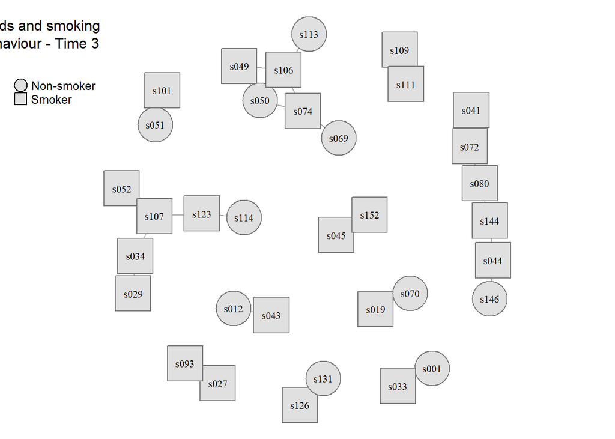

```r
# Make an Igraph object
g_tb3 <- graph_from_adjacency_matrix(f_tb3,
                                  mode="undirected",
                                  #weighted = NULL,
                                  diag = F)

# Color the nodes by smoking behavior
V(g_tb3)$shape <- ifelse(df_smoking_3$smoke== "No", "circle", "square")

isolated_tb3 <- which(degree(g_tb3)==0)
g_tb3 <- delete.vertices(g_tb3, isolated_tb3)

# Plot
par(mar=c(0,0,0,0))
plot(g_tb3, layout=layout_nicely(g_tb3),
     vertex.size=19,
     vertex.label.cex=0.7,
     vertex.color = "grey88",
     vertex.frame.color="gray48",
     vertex.label.color= "black")
text(-1.5,1,"   Friends and smoking
     behaviour - Time 3", cex=1)
legend(x=-1.6, y=0.8,
       legend= c("Non-smoker", "Smoker"),
       pch = c(21,22),  pt.bg= c('gray88', "gray88"),
       bty = "n" , pt.cex = 2, cex = 0.8,
       text.col="black" , horiz = F)
```

## Third matrix: gender (1 = same, 0 = different)

1. Create a matrix where 1 stands for same gender, 0 different.

```r
same_gender_3 <- outer(gender, gender, function(a, b) as.integer(a == b))
dimnames(same_gender_3) <- list(rownames(f3), rownames(f3))
#head(same_gender)
```

2. Now, let’s perform an elementwise multiplication between the second matrix (friends and regular smoking behavior at time 1), with the gender matrix.

```r
f_tb3_gdr = f_tb3 * same_gender_3
```

### Visualize network of friends weighted by smoking behaviour and according to their gender at time 3

```r
#Create a dataframe with gender for each subject
df_gender_3 <- data.frame(sex = sex.F, name = rownames(sex.F) )
df_gender_3 <- df_gender_3[!rownames(df_gender_3) %in% rn_na,]
df_gender_smoking_3 <- merge(df_gender_3, df_smoking_3)
```

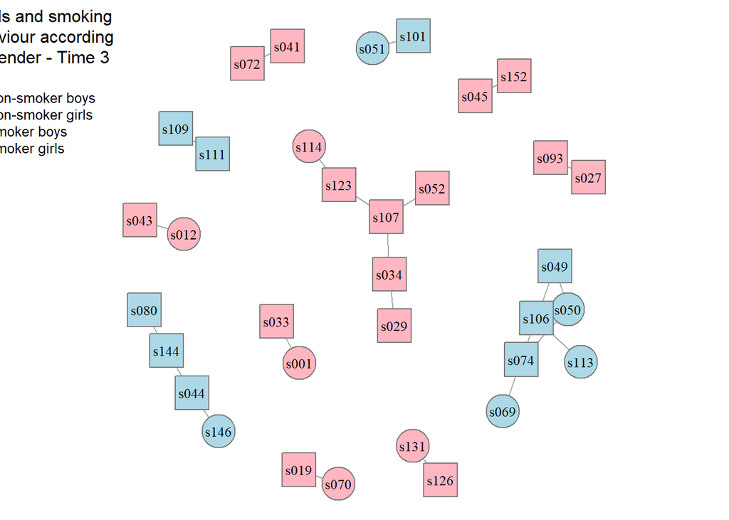

```r
# Make an Igraph object
g_tb3_gdr <- graph_from_adjacency_matrix(f_tb3_gdr,
                                  mode="undirected",
                                  #weighted = NULL,
                                  diag = F)

# Color the nodes by gender
V(g_tb3_gdr)$color <- ifelse(df_gender_3$sex == 1, "lightblue", "lightpink")
V(g_tb3_gdr)$shape <- ifelse(df_gender_smoking_3$smoke== "No", "circle", "square")


isolated_tb3_gdr <- which(degree(g_tb3_gdr)==0)
g_tb3_gdr <- delete.vertices(g_tb3_gdr, isolated_tb3_gdr)

# Plot
par(mar=c(0,0,0,0))
#plot(g1, layout = layout_nicely(g1))
plot(g_tb3_gdr, layout=layout_nicely(g_tb3_gdr),
     vertex.size=15,
     vertex.color=V(g_tb3_gdr)$color,
     vertex.label.cex=0.8,
     vertex.frame.color="gray48",
     vertex.label.color= "black")
text(-1.5,1,"   Friends and smoking
     behaviour according
     to gender - Time 3", cex=1)
legend(x=-1.8, y=0.8,
       legend= c("Non-smoker boys", "Non-smoker girls", "Smoker boys", "Smoker girls"),
       col = c("lightblue", "lightpink", "lightblue", "lightpink"),
       pch = c(21, 21, 22, 22),  pt.bg= c("lightblue", "lightpink", "lightblue", "lightpink"),
       bty = "n",  pt.cex = 2, cex = 0.8,
       text.col="black" , horiz = F)
```

# Regression

First, let’s create a data frame, with subjects as rows (n=131) and four columns:

1. *n_f* = number of friends at time 1, given by the row sum in the first matrix (friendship).
2. *n_fs* = number of smoker friends (occasional or regular) at time 1, by taking the sum of corresponding row for each student in the second matrix.
3. *n_fsg* = number of smoker friends with the same gender as the subject. It is obtained by taking the sum of each row in the third matrix.
4. *smoking* = smoking behavior at time 3. This is the output variable.

```r
# n_f = number of friends at time 1.
n_f = rowSums(f1)

# n_fs = number of smoker friends
n_fs = rowSums(f_tb1)

# n_fsg = number of smoker friends with the same gender as the subject
n_fsg = rowSums(f_tb1_gdr)

# tb3 = smoking behavior at time 3.
tb3 <- as.vector(tobacco$t3)
setNames(tb3, rownames(tobacco))
```

```
## s001 s002 s003 s004 s005 s006 s007 s008 s010 s011 s012 s013 s014 s015 s016 s018
##    1    1    3    1    1    3    1    1    1    1    1    3    1    3    3    1
## s019 s020 s021 s022 s023 s026 s027 s028 s029 s030 s032 s033 s034 s035 s036 s037
##    3    1    1    1    1    1    2    1    3    1    1    3    3    1    1    1
## s038 s039 s041 s042 s043 s044 s045 s046 s047 s049 s050 s051 s052 s053 s054 s055
##    1    1    3    1    2    3    2    1    3    2    1    1    3    1    1    1
## s056 s057 s058 s059 s060 s061 s062 s064 s065 s066 s068 s069 s070 s071 s072 s073
##    1    1    1    1    1    1    1    3    3    1    1    1    1    1    3    1
## s074 s075 s076 s077 s078 s079 s080 s081 s082 s083 s084 s085 s086 s087 s088 s089
##    3    3    1    1    1    1    3    3    1    1    1    1    1    3    1    1
## s090 s091 s092 s093 s095 s097 s098 s099 s100 s101 s105 s106 s107 s108 s109 s110
##    1    1    1    3    1    1    2    1    1    2    1    3    3    1    3    1
## s111 s112 s113 s114 s115 s116 s117 s118 s120 s121 s122 s123 s125 s126 s127 s130
##    3    1    1    1    3    1    1    1    1    1    1    3    1    3    1    1
## s131 s132 s134 s135 s137 s138 s139 s140 s141 s142 s143 s144 s146 s147 s148 s149
##    1    1    1    1    1    1    1    1    1    1    1    3    1    1    1    1
## s150 s151 s152
##    1    1    3
```

```r
tb3[tb3 == 1] <- 0  # non-smoker
tb3[tb3 == 3| tb3 == 2] <- 1 #regular or occasional smoker
```

```r
#df_r is "data frame for regression"

df_r = data.frame(n_f, n_fs, n_fsg, tb1, tb3)
head(df_r, 10)
```

|  | n_f | n_fs | n_fsg | tb1 | tb3 |
| --- | --- | --- | --- | --- | --- |
| s001 | 1 | 0 | 0 | 1 | 0 |
| s002 | 0 | 0 | 0 | 0 | 0 |
| s003 | 0 | 0 | 0 | 1 | 1 |
| s004 | 0 | 0 | 0 | 0 | 0 |
| s005 | 1 | 0 | 0 | 0 | 0 |
| s006 | 0 | 0 | 0 | 1 | 1 |
| s007 | 1 | 0 | 0 | 0 | 0 |
| s008 | 1 | 0 | 0 | 0 | 0 |
| s010 | 0 | 0 | 0 | 0 | 0 |
| s011 | 0 | 0 | 0 | 0 | 0 |

```r
logistic_model <- glm(tb3 ~ n_f + n_fs + n_fsg,
                      data = df_r,
                      family = "binomial")

# Summary
summary(logistic_model)
```

```
##
## Call:
## glm(formula = tb3 ~ n_f + n_fs + n_fsg, family = "binomial",
##     data = df_r)
##
## Deviance Residuals:
##     Min       1Q   Median       3Q      Max
## -1.6017  -0.8267  -0.6995   0.8059   1.7480
##
## Coefficients:
##              Estimate Std. Error z value Pr(>|z|)
## (Intercept)   -0.8979     0.2507  -3.581 0.000342 ***
## n_f           -0.3852     0.2885  -1.335 0.181801
## n_fs         -13.8978  1455.3976  -0.010 0.992381
## n_fsg         16.1389  1455.3977   0.011 0.991152
## ---
## Signif. codes:  0 '***' 0.001 '**' 0.01 '*' 0.05 '.' 0.1 ' ' 1
##
## (Dispersion parameter for binomial family taken to be 1)
##
##     Null deviance: 155.95  on 130  degrees of freedom
## Residual deviance: 144.53  on 127  degrees of freedom
## AIC: 152.53
##
## Number of Fisher Scoring iterations: 14
```

```r
exp(-0.3852)  # number of friends
```

```
## [1] 0.6803146
```

The regression coefficient for *n_f* is -0.3852. An increase of one unit in the number of friends at time 1 is associated with a decrease in the probability of being smokers at time 3 of exp(-0.3852) = 0.68 times.

There is no clear evidence of a real association between the number of friends at time 1 *n_f* and the smoking behavior at time 3 *tb_3*. In fact, at the value of 0.18, the p-value of the estimated coefficient is relatively large. We accept the null-hypothesis that the coefficient in question is zero.

Also the other statistical tests resulted in non-significant p-values. This can be due to the correlation between the set of predictors. As shown below, if taken on its own, the variable *n_fs*, the number of smoker friends at time 1, is significant and with positive sign.

```r
cor(df_r)
```

```
##               n_f      n_fs     n_fsg         tb1         tb3
## n_f    1.00000000 0.3479609 0.3226233 -0.01762352 -0.02699886
## n_fs   0.34796087 1.0000000 0.9607925  0.21425366  0.24913159
## n_fsg  0.32262329 0.9607925 1.0000000  0.23211838  0.27326877
## tb1   -0.01762352 0.2142537 0.2321184  1.00000000  0.44085403
## tb3   -0.02699886 0.2491316 0.2732688  0.44085403  1.00000000
```

The variables *n_fs*, the number of smoker friends, and *n_fsg*, the number of smoker friends of the same gender, have a correlation coefficient $\rho = 0.96$.

```r
logistic_model_n_fs <- glm(tb3 ~ n_f + n_fs,
                      data = df_r,
                      family = "binomial")


summary(logistic_model_n_fs)
```

```
##
## Call:
## glm(formula = tb3 ~ n_f + n_fs, family = "binomial", data = df_r)
##
## Deviance Residuals:
##     Min       1Q   Median       3Q      Max
## -1.4963  -0.8297  -0.6950   0.8890   1.7545
##
## Coefficients:
##             Estimate Std. Error z value Pr(>|z|)
## (Intercept)  -0.8894     0.2502  -3.554 0.000379 ***
## n_f          -0.4081     0.2908  -1.403 0.160508
## n_fs          2.0218     0.7121   2.839 0.004520 **
## ---
## Signif. codes:  0 '***' 0.001 '**' 0.01 '*' 0.05 '.' 0.1 ' ' 1
##
## (Dispersion parameter for binomial family taken to be 1)
##
##     Null deviance: 155.95  on 130  degrees of freedom
## Residual deviance: 146.41  on 128  degrees of freedom
## AIC: 152.41
##
## Number of Fisher Scoring iterations: 4
```

```r
exp(2.0218)
```

```
## [1] 7.551906
```

By considering only the number of smoking friends at time 1 (*n_fs*), the estimated coefficient $\beta_{NFS}$ in the logit model is equal to $2.0218$ Again, this means that for one unite increase in the number of friends who smoke, the probability of being a smoker at time 3 increases by approximately 7.5 times. Since the p-value is lower than $\alpha$ = 0.05, we reject the null-hypothesis of the estimate being equal to zero. That is to say, there is a strong and statistically significant association between the predictor and the outcome.

```r
logistic_model_n_fsg <- glm(tb3 ~ n_f + n_fsg,
                      data = df_r,
                      family = "binomial")


summary(logistic_model_n_fsg)
```

```
##
## Call:
## glm(formula = tb3 ~ n_f + n_fsg, family = "binomial", data = df_r)
##
## Deviance Residuals:
##     Min       1Q   Median       3Q      Max
## -1.6063  -0.8275  -0.6940   0.8024   1.7559
##
## Coefficients:
##             Estimate Std. Error z value Pr(>|z|)
## (Intercept)  -0.8957     0.2509  -3.570 0.000357 ***
## n_f          -0.4051     0.2882  -1.405 0.159892
## n_fsg         2.2690     0.7664   2.961 0.003070 **
## ---
## Signif. codes:  0 '***' 0.001 '**' 0.01 '*' 0.05 '.' 0.1 ' ' 1
##
## (Dispersion parameter for binomial family taken to be 1)
##
##     Null deviance: 155.95  on 130  degrees of freedom
## Residual deviance: 144.87  on 128  degrees of freedom
## AIC: 150.87
##
## Number of Fisher Scoring iterations: 4
```

```r
exp(2.2690)
```

```
## [1] 9.669726
```

For one unite increase in the number of smoker friends of the same gender at time 1 *n_fsg*, there is an increase in the odds of becoming a smoker at time 3 of at least 9 times. We reject the null-hypothesis of the coefficient being zero, i.e. there is statistical evidence underlying the association between the number of smoker friends of the same gender as the subject and smoking initiation in the following two years.